# STAT 992 S23: Week 3

2023-02-05

These notes show how we can use `MultiAssayExperiment` to run Multi-Omic Gene Set Analysis (MOGSA) on the Type 1 Diabetes study from [DIABIMMUNE](https://diabimmune.broadinstitute.org/diabimmune/t1d-cohort). It follows ``Integrated Single Sample Gene Set Enrichment Analysis’’ from the paper’s supplementary material.

## MAE Construction

We’ll need the libraries below. Note that Bioconductor packages are installed using `BiocManager`, not `install.packages()`. The commented code shows to install these packages in case you don’t already have them.

```r
# install.packages("BiocManager")
# BiocManager::install(c("MultiAssayExperiment", "mogsa", "curatedMetagenomicData", "genefilter"))
library(MultiAssayExperiment)
library(curatedMetagenomicData)
library(genefilter)
library(gplots)
library(mogsa)
library(tidyverse)
theme_set(theme_bw())
```

The block below downloads the 16S microbiome and metagenomic data from the Type 1 Diabetes study. The two datasets have exactly matching samples, but there are more metagenomic features (gene pathways) than 16S taxa. The metagenomics data give an idea of whether certain biological pathways are more active in some phenotypes, even if these pathways are spread out across many different taxa.

```r
kostic_taxa <- curatedMetagenomicData("KosticAD_2015.relative_abundance", dryrun = FALSE, rownames = "short")
kostic_genes <- curatedMetagenomicData("KosticAD_2015.pathway_coverage", dryrun = FALSE, rownames = "short")
mae <- MultiAssayExperiment(c(kostic_taxa, kostic_genes))
```

We’ll want to keep track of the sample descriptors. The study metadata is contained in a global object called `sampleMetadata` which is exported by the `curatedMetagenomicData` package. We’ll extract the subset for the current study and merge it into our updated MAE in the next section.

```r
metadata <- sampleMetadata %>%
  filter(study_name == "KosticAD_2015") %>%
  select(sample_id, subject_id, disease, disease_subtype, infant_age, country, born_method, feeding_practice) %>%
  DataFrame()
rownames(metadata) <- sampleNames(kostic_taxa)
```

## Filtering Features

There are 328 taxa and 12079 gene pathways in the raw data. However, most are present in only low abundances. To improve power, it can be helpful to filter down to those features that are present in higher abundances. We are willing to sacrifice potential signal in the sparse features in order to reduce the problem dimensionality over all. The code below filters down to taxa and genes that are present in at least 5 and 20% of samples, respectively.

```r
keep_ix <- map2(assays(mae), c(0.05, 0.2), ~ genefilter(.x, pOverA(.y, 0)))
keep_ix[[1]] <- keep_ix[[1]] & !is.na(rowData(mae[[1]])$genus)
keep_ix[[2]] <- keep_ix[[2]] & str_detect(names(keep_ix[[2]]), "g_")
mae <- map2(mae, keep_ix, ~ .x[.y, ]) %>%
  MultiAssayExperiment(colData = metadata)
```

## Preparing MOGSA Input

The MOGSA technique unifies features from across sources by using shared gene sets. The idea is that, if each original feature can be assigned to a gene set that is can be interpreted across sources, then the final results should be presented in terms of gene set activity. Specifically, MOGSA sums factor loadings from each source according to their gene set membership:

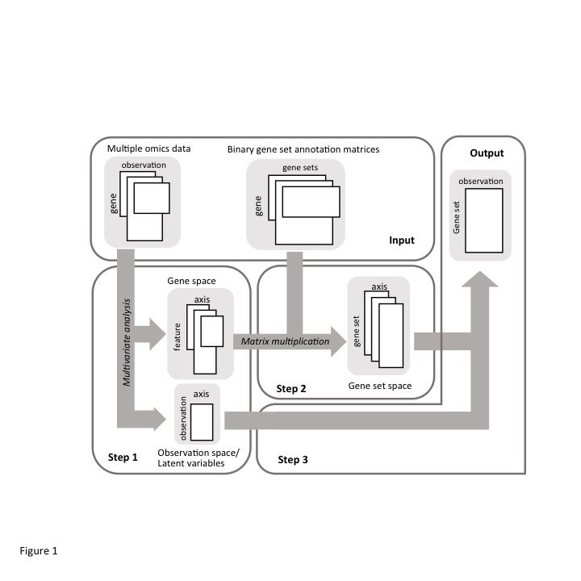

Therefore, to apply this method to the Type 1 Diabetes data, we need to define something analogous to gene sets. In this context, we will use bacterial genus – this is possible because each gene pathway is already given a taxonomic assignment. The block below makes these assignments by parsing the `rowData` and rownames from the MAE sources. Finally, we filter to only those genera that are shared across sources.

```r
xs <- map(mae, ~ as.data.frame(assay(.)))

supp <- list(
  model.matrix(~ -1 + genus, data = rowData(mae[[1]])) %>%
    as.matrix(),
  str_extract(rownames(mae[[2]]), "g__[A-z]+") %>%
    data.frame(genus = str_remove(., "g__")) %>%
    model.matrix(~ -1 + genus, .)
)

intersect_cols <- intersect(colnames(supp[[1]]), colnames(supp[[2]]))
supp[[1]] <- supp[[1]][, intersect_cols]
supp[[2]] <- supp[[2]][, intersect_cols]
```

## MOGSA Interpretation

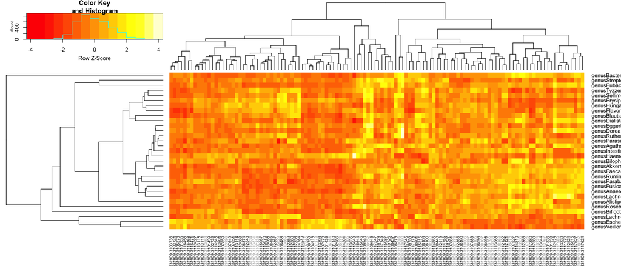

```r
fit <- mogsa(xs, supp, nf = 10, proc.row = "center_ssq1", w.data = "inertia")
scores <- getmgsa(fit, "score")
cols <- c("#A6A6A6", "#0D0D0D")[as.factor(colData(mae)$disease)]
heatmap.2(scores, trace = "n", scale = "r", colCol = cols)
```

We can also make a PCA-like figure of latent sample scores and factor loadings.

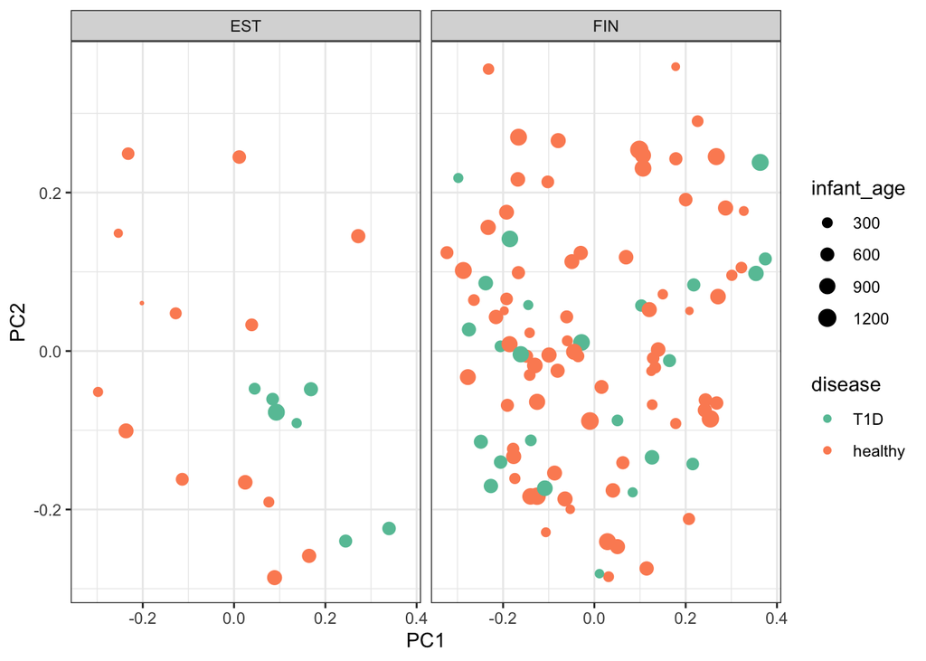

```r
fs <- getmgsa(fit, "fac.scr")  %>%
  as_tibble() %>%
  select(PC1:PC4) %>%
  bind_cols(as_tibble(colData(mae)))

ggplot(fs) +
  geom_point(aes(PC1, PC2, col = disease, size = infant_age)) +
  scale_color_brewer(palette = "Set2") +
  scale_size(range = c(0.5, 4)) +
  facet_wrap(~ country)
```

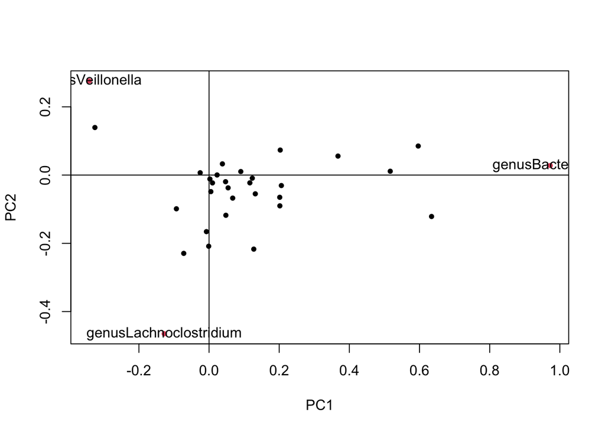

```r
plotGS(fit, center.only = TRUE)
```

## Extending S4 Classes

Let’s step back from this specific data analysis and reflect on the value of defining a `MultiAssayExperiment` object in the first place. Much of what we’ve done did not actually need much more than a simple list of `SummarizedExperiment`. However, being able to define methods for a well-defined class can often be helpful. In the example below, we extend the `MultiAssayExperiment` class into our own `myMAE` class, so that we can give it its own `cor` method. We will overwrite the default `cor` command for the case that the input object has class `myMAE`, and in this case, it will return a list showing the pairwise correlation between features from across sources.

We accomplish this by defining a new class through `setClass` and defining a `cor` method specific to this class using `setMethod`. Our specialized cor function is `mae_cor` – it loops over assays and computes their pairwise correlations.

```r
mae_corr <- function(x) {
  xs <- assays(x)
  nm <- names(x)

  corr <- list()
  for (i in seq_along(x)) {
    for (j in seq_len(i - 1)) {
      corr[[paste0(nm[i], "-", nm[j])]] <- cor(t(xs[[i]]), t(xs[[j]]))
    }
  }

  corr
}

setClass("myMAE", contains = "MultiAssayExperiment")
setMethod("cor", signature(x = "myMAE"), mae_corr)
```

We can now apply this correlation method to the previous MAE object. Even after variance stabilization, the correlation is quite far from normal.

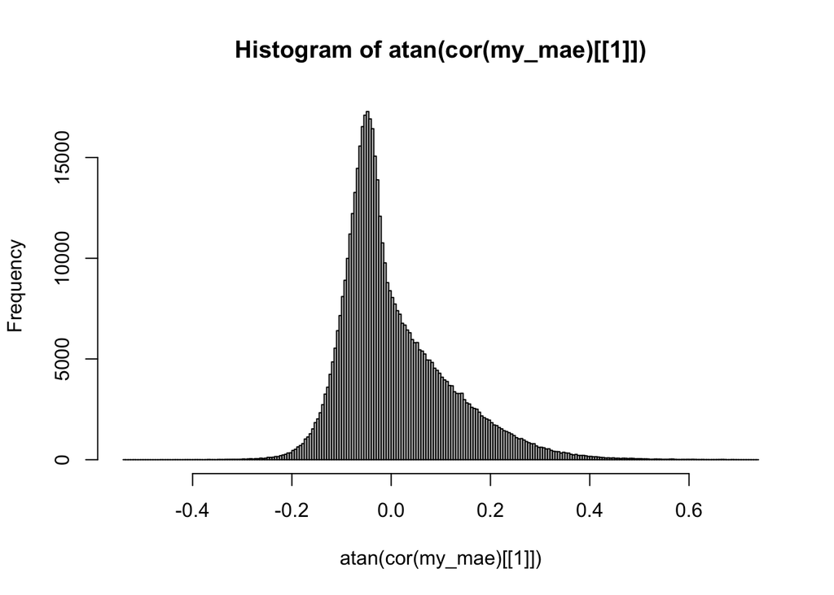

```r
my_mae <- as(mae, "myMAE")
hist(atan(cor(my_mae)[[1]]), breaks = 200)
```